# SingleWord CFS

Hugh Rabagliati

29 August 2016

### Background

This is an attempt to conduct an English-language replication of Yang and Yeh (2011, Consc. & Cogn). That paper showed that **neutral** words break suppression **more quickly** than **negative** words.

In our replication, participants saw 300 words, in a 2*2 design that crossed Emotional Content (Negative vs Neutral words) and Length (Short vs Long words). Emotional ratings were taken from the Florida Affective Norms for English Words.

We have a smaller number of subjects than our other experiments (28 total, 26 after exclusions), because participants saw many more critical trials than most comparable experiments.

```r
sense.pop <- read_data("./data/")
sense.pop$length <- "Short words"
sense.pop[sense.pop$info %in% c("long negative","long neutral"),]$length <- "Long words"
sense.pop <- subset(sense.pop, rt != "None")
sense.pop$rt <- as.numeric(sense.pop$rt)

# Remove outlier subjects by Accuracy and RT (mean acc must be > 0.9, mean rt must be < 3sd above group mean)
Acc <- summaryBy(match. + rt ~ SubjNo, data = subset(sense.pop), keep.names = T)
sense.pop <- subset(sense.pop, SubjNo %in% Acc[Acc$match. > 0.9,]$SubjNo)
sense.pop <- subset(sense.pop, SubjNo %in% Acc[Acc$rt < (mean(Acc$rt) + (3*sd(Acc$rt))),]$SubjNo)

# Remove incorrect trials
sense.pop <- subset(sense.pop, match. == 1)

# Remove RTs < 200ms
sense.pop <- subset(sense.pop, rt > 0.2)
#sense.pop$rt.log <- log(sense.pop$rt)

sense.pop$length <- ordered(sense.pop$length, levels = c("Short words","Long words"))
sense.pop$prime_semantics <- ordered(sense.pop$prime_semantics, levels = c("negative","neutral"))
contrasts(sense.pop$length)[1] <- -1
contrasts(sense.pop$prime_semantics)[1] <- -1
```

## Untransformed data

#### Plot RT distribution

As seen below, there is considerable skew in the raw RT data (upper plot), which somewhat remains after log transforming the RTs (lower plot).

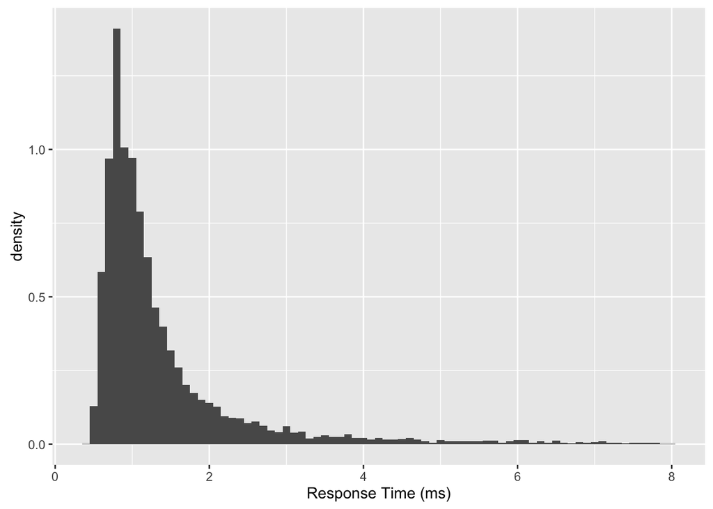

#### Plot Summaries

These bar plots suggest that the effect of Length is considerably greater than any effect of Emotional Content.

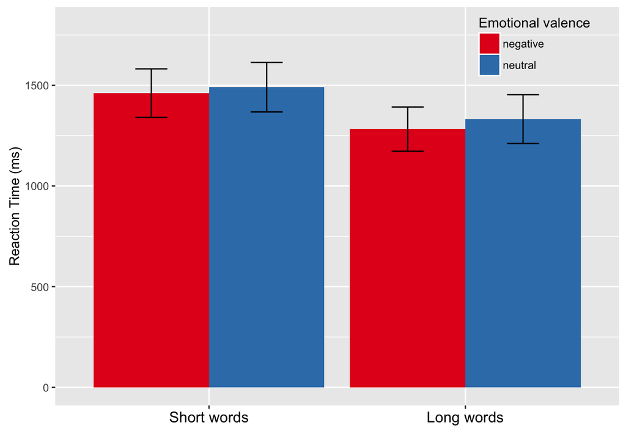

#### Analyze data

Statistical analyses show a robust effect of Length, and no effect of Emotional Content. This holds for both the raw data (top analysis) and the log transformed data (bottom analysis).

```
##               .L
## Short -1.0000000
## Long   0.7071068
```

```
## Linear mixed model fit by REML ['lmerMod']
## Formula: rt ~ prime_semantics * length + (1 + prime_semantics + length |
##     SubjNo) + (1 | word)
##    Data: sense.pop
##
## REML criterion at convergence: 19040.2
##
## Scaled residuals:
##     Min      1Q  Median      3Q     Max
## -2.5542 -0.3886 -0.1658  0.1168  7.9246
##
## Random effects:
##  Groups   Name              Variance  Std.Dev. Corr
##  word     (Intercept)       0.0084002 0.09165
##  SubjNo   (Intercept)       0.3493064 0.59102
##           prime_semantics.L 0.0003602 0.01898   1.00
##           length.L          0.0065867 0.08116  -0.23 -0.23
##  Residual                   0.7343825 0.85696
## Number of obs: 7431, groups:  word, 300; SubjNo, 26
##
## Fixed effects:
##                             Estimate Std. Error t value
## (Intercept)                 1.380439   0.116495  11.850
## prime_semantics.L           0.022808   0.013892   1.642
## length.L                   -0.100333   0.020831  -4.817
## prime_semantics.L:length.L  0.002563   0.015460   0.166
##
## Correlation of Fixed Effects:
##             (Intr) prm_.L lngt.L
## prm_smntc.L  0.283
## length.L    -0.166 -0.029
## prm_sm.L:.L  0.003  0.161  0.108
## convergence code: 0
## Model failed to converge with max|grad| = 2.37546 (tol = 0.002, component 1)
## Model is nearly unidentifiable: large eigenvalue ratio
##  - Rescale variables?
```

```
## [1] "p value =  2.15791268842054e-32" "p value =  0.100617695244703"
## [3] "p value =  1.46024118610883e-06" "p value =  0.868335266075758"
```

```
##
##  Paired t-test
##
## data:  rt by prime_semantics
## t = -1.4788, df = 25, p-value = 0.1517
## alternative hypothesis: true difference in means is not equal to 0
## 95 percent confidence interval:
##  -0.11925561  0.01957349
## sample estimates:
## mean of the differences
##             -0.04984106
```

```
##
##  Paired t-test
##
## data:  rt by prime_semantics
## t = -0.94849, df = 25, p-value = 0.352
## alternative hypothesis: true difference in means is not equal to 0
## 95 percent confidence interval:
##  -0.09353916  0.03454983
## sample estimates:
## mean of the differences
##             -0.02949466
```

## Log transformed data

```r
sense.pop <- read_data("./data/")
sense.pop$length <- "Short"
sense.pop[sense.pop$info %in% c("long negative","long neutral"),]$length <- "Long"
sense.pop <- subset(sense.pop, rt != "None")
sense.pop$rt <- log(as.numeric(sense.pop$rt))

# Remove outlier subjects by Accuracy and RT (mean acc must be > 0.9, mean rt must be < 3sd above group mean)
Acc <- summaryBy(match. + rt ~ SubjNo, data = subset(sense.pop), keep.names = T)
sense.pop <- subset(sense.pop, SubjNo %in% Acc[Acc$match. > 0.9,]$SubjNo)
sense.pop <- subset(sense.pop, SubjNo %in% Acc[Acc$rt < (mean(Acc$rt) + (3*sd(Acc$rt))),]$SubjNo)

# Remove incorrect trials
sense.pop <- subset(sense.pop, match. == 1)

# Remove RTs < 200ms
sense.pop <- subset(sense.pop, rt > log(0.2))
#sense.pop$rt.log <- log(sense.pop$rt)
sense.pop$length <- as.factor(sense.pop$length)
sense.pop$prime_semantics <- as.factor(sense.pop$prime_semantics)
contrasts(sense.pop$length)[1] <- -1
contrasts(sense.pop$prime_semantics)[1] <- -1
```

#### Plot RT distribution

As seen below, there is considerable skew in the raw RT data (upper plot), which somewhat remains after log transforming the RTs (lower plot).

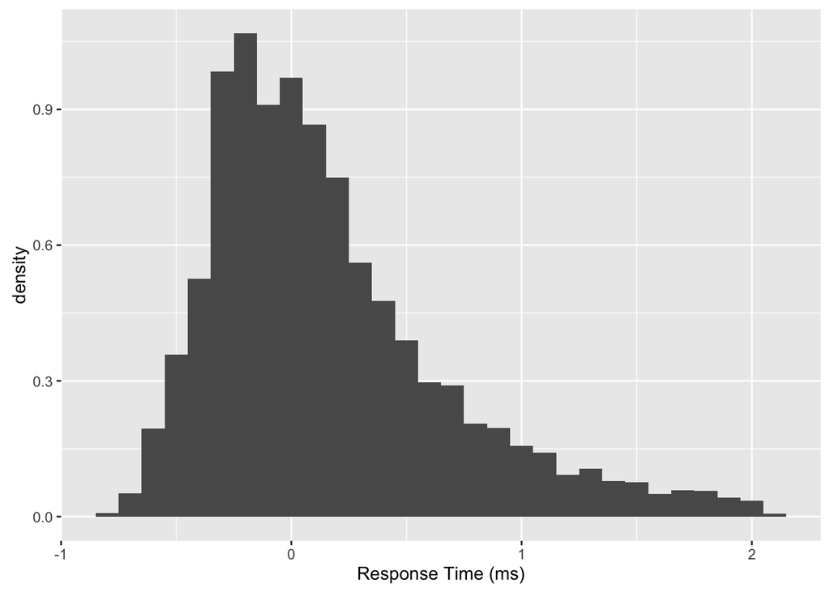

#### Plot Summaries

These bar plots suggest that the effect of Length is considerably greater than any effect of Emotional Content.

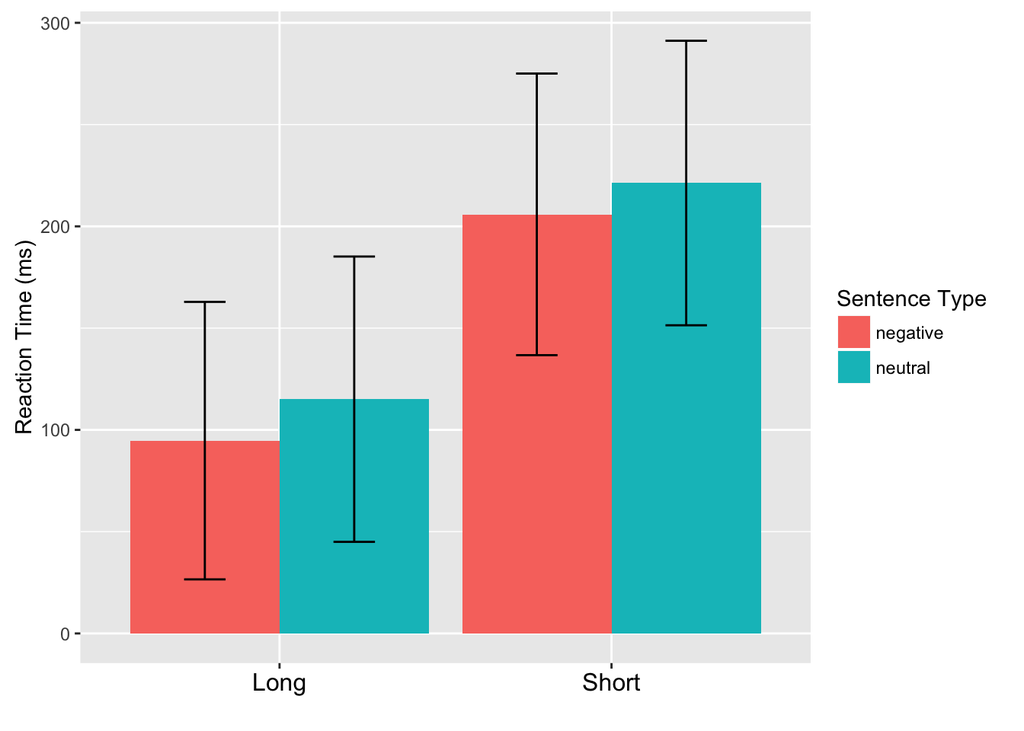

#### Analyze data

Statistical analyses show a robust effect of Length, and no effect of Emotional Content. This holds for both the raw data (top analysis) and the log transformed data (bottom analysis).

```
## Linear mixed model fit by REML ['lmerMod']
## Formula: rt ~ prime_semantics * length + (1 + prime_semantics * length |
##     SubjNo) + (1 | word)
##    Data: sense.pop
##
## REML criterion at convergence: 7349
##
## Scaled residuals:
##     Min      1Q  Median      3Q     Max
## -2.9441 -0.5990 -0.1800  0.4094  5.7655
##
## Random effects:
##  Groups   Name                               Variance  Std.Dev. Corr
##  word     (Intercept)                        2.355e-03 0.048525
##  SubjNo   (Intercept)                        1.213e-01 0.348293
##           prime_semanticsneutral             6.864e-05 0.008285  0.25
##           lengthShort                        1.232e-03 0.035098  0.05
##           prime_semanticsneutral:lengthShort 2.744e-04 0.016564 -0.11
##  Residual                                    1.511e-01 0.388729
##
##
##
##
##  -0.90
##  -0.81  0.56
##
## Number of obs: 7431, groups:  word, 300; SubjNo, 26
##
## Fixed effects:
##                                      Estimate Std. Error t value
## (Intercept)                         1.593e-01  6.851e-02   2.325
## prime_semanticsneutral              8.631e-03  5.554e-03   1.554
## lengthShort                         5.483e-02  8.706e-03   6.297
## prime_semanticsneutral:lengthShort -3.646e-05  6.231e-03  -0.006
##
## Correlation of Fixed Effects:
##             (Intr) prm_sm lngthS
## prm_smntcsn  0.072
## lengthShort  0.036 -0.210
## prm_smntc:S -0.056 -0.123  0.233
```

```
## [1] "p value =  0.0200762697126125"   "p value =  0.120170195074544"
## [3] "p value =  3.02720268857804e-10" "p value =  0.995331688148238"
```

```
##
##  Paired t-test
##
## data:  rt by prime_semantics
## t = -1.2245, df = 25, p-value = 0.2322
## alternative hypothesis: true difference in means is not equal to 0
## 95 percent confidence interval:
##  -0.05459800  0.01388264
## sample estimates:
## mean of the differences
##             -0.02035768
```

```
##
##  Paired t-test
##
## data:  rt by prime_semantics
## t = -1.21, df = 25, p-value = 0.2376
## alternative hypothesis: true difference in means is not equal to 0
## 95 percent confidence interval:
##  -0.04159759  0.01080840
## sample estimates:
## mean of the differences
##             -0.01539459
```